# Coursera Practical Machine Learning - Course Assignment

Honto Ming

June 13, 2015

# Introduction

For the Coursera Practical Machine Learning Course Assignment, we will attemp to detect if a person made mistakes when performing Unilateral Dumbell Bicep Curls from data captured through sensors on various parts of the the participant’s body and on the dumbell. The data we are using is obtained from Velloso et. al’s paper “Qualitative Activity Recognition of Weight Lifting Exercises” [1]

The data can be obtained through their website at [link](http://groupware.les.inf.puc-rio.br/har)

# Data Cleaning

Prior to building any models or splitting the data into testing and training sets, we first have to transform the data set so that it follows the clean and tidy data principles set out in the Getting and Cleaning Data Course.

The data set contains 19622 observations with 160 variables. First, we removed 100 variables where more than 90% of observations were blank, NA or somehow invalid. Then, we removed variables that are not considered as predictors (i.e. not from sensor data such as user_name)

We then split up the data into training and testign sets with a 60-40 train-test split.

# Exploratory Analysis

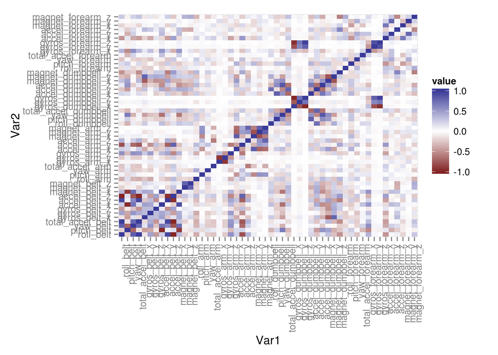

# Preprocessing

Next, we examine if there are any zero variance or near zero variance variables using the nearZeroVar() function with the default freqCut and uniqueCut of 95/5 and 10, respectively. The results show that there are no near zero variance values so we can proceed.

Otherwise, the data seems to be tidy, and since we will be using tree-based classification model, standardizing the variables will not have an impact on accuracy. We will perform no pre-processing at this time.

# Model Training and Tuning

For model selection and tuning of parameters, we will use the extensive tools provided by the caret package. For this assignment, we will train the following models and their associated parameters:

| Model | Tuning Parameters |
| --- | --- |
| Classification Tree (rpart) | complexity (cp) |
| Random Forest (rf) | # of variables at split (mtry) |
| Stochastic Gradient Boosting (gbm) | n.trees, interaction.depth, shrinkage |

We will use 10-fold cross validation to obtain an estimated out-of-sample error to determine the best performing model.

Results from the training:

## Classification Trees

We will use use the following values for tuning the complexity tuning parameter (cp) in our tuning grid to determine which value we should use:

```r
# tuning grid for cp
cart.grid <- expand.grid(cp=c(0.00001, 0.00005, 0.0001, 0.0005, 0.001, 0.005, 0.01))
```

```
## CART
##
## 11776 samples
##    52 predictors
##     5 classes: 'A', 'B', 'C', 'D', 'E'
##
## No pre-processing
## Resampling: Cross-Validated (10 fold)
##
## Summary of sample sizes: 10599, 10599, 10598, 10598, 10599, 10598, ...
##
## Resampling results across tuning parameters:
##
##   cp     Accuracy   Kappa      Accuracy SD  Kappa SD
##   1e-05  0.9171191  0.8951875  0.008453956  0.01065303
##   5e-05  0.9176286  0.8958313  0.008414343  0.01060654
##   1e-04  0.9175436  0.8957202  0.008873247  0.01118353
##   5e-04  0.9122790  0.8890587  0.008819556  0.01110303
##   1e-03  0.8991166  0.8723986  0.009140515  0.01150495
##   5e-03  0.7986581  0.7451178  0.015055056  0.01929476
##   1e-02  0.7247780  0.6507244  0.015181239  0.01951505
##
## Accuracy was used to select the optimal model using  the largest value.
## The final value used for the model was cp = 5e-05.
```

As we can see from the results, the optimal parameters for a CART model is cp=0.00005 resulting in an estiamted out-of-sample error of just 0.08.

## Random Forest

For Random Forest, we will use use the following values for tuning the the mtry parameter which controls how many variables will be considered to split at each node:

```r
# tuning grid for mtry
rf.grid <- expand.grid(mtry=c(3,5,7,9,11))
```

Note that the tuning values are around the suggested value of $\sqrt{p}$ where $p$ equal the number of covariates.

```
## Random Forest
##
## 11776 samples
##    52 predictors
##     5 classes: 'A', 'B', 'C', 'D', 'E'
##
## No pre-processing
## Resampling: Cross-Validated (10 fold)
##
## Summary of sample sizes: 10599, 10599, 10598, 10598, 10599, 10598, ...
##
## Resampling results across tuning parameters:
##
##   mtry  Accuracy   Kappa      Accuracy SD  Kappa SD
##    3    0.9910832  0.9887191  0.002724065  0.003446107
##    5    0.9930365  0.9911909  0.001827117  0.002310836
##    7    0.9930364  0.9911910  0.002186692  0.002765595
##    9    0.9934612  0.9917285  0.002230957  0.002821545
##   11    0.9937160  0.9920506  0.002200065  0.002782778
##
## Accuracy was used to select the optimal model using  the largest value.
## The final value used for the model was mtry = 11.
```

## Boosted Trees

The gbm model has more tuning parameters, and being too extreme with a number of these tuning parameters may cause overfitting. Also, with using 10-fold cross-validation, each new value added to a parameter in the tuning grid has a multiplicative effect on the number of runs that need to be done. Hence, we are going to keep shrinkage constant at 0.1

```r
# tuning grid for mtry
gbm.grid <- expand.grid(interaction.depth=c(1,2,4,6,8),
                        n.trees=c(50, 100, 150, 200, 250),
                        shrinkage=0.1)
```

```
## Stochastic Gradient Boosting
##
## 11776 samples
##    52 predictors
##     5 classes: 'A', 'B', 'C', 'D', 'E'
##
## No pre-processing
## Resampling: Cross-Validated (10 fold)
##
## Summary of sample sizes: 10599, 10599, 10598, 10598, 10599, 10598, ...
##
## Resampling results across tuning parameters:
##
##   interaction.depth  n.trees  Accuracy   Kappa      Accuracy SD
##   1                   50      0.7546710  0.6890369  0.010067675
##   1                  100      0.8210767  0.7736388  0.009408572
##   1                  150      0.8549596  0.8165097  0.008418396
##   1                  200      0.8757640  0.8427744  0.006571960
##   1                  250      0.8877378  0.8579207  0.007420858
##   2                   50      0.8563178  0.8180131  0.009913163
##   2                  100      0.9062499  0.8814043  0.005479520
##   2                  150      0.9293478  0.9106021  0.004631039
##   2                  200      0.9452281  0.9306954  0.005572055
##   2                  250      0.9552484  0.9433788  0.005642625
##   4                   50      0.9198365  0.8985401  0.007539346
##   4                  100      0.9573705  0.9460644  0.006162085
##   4                  150      0.9728255  0.9656230  0.005081962
##   4                  200      0.9791096  0.9735729  0.004260227
##   4                  250      0.9839500  0.9796973  0.005211066
##   6                   50      0.9468411  0.9327157  0.006699877
##   6                  100      0.9757975  0.9693825  0.006740156
##   6                  150      0.9840354  0.9798056  0.003792396
##   6                  200      0.9876019  0.9843171  0.003470447
##   6                  250      0.9897248  0.9870029  0.003721051
##   8                   50      0.9637396  0.9541181  0.005815463
##   8                  100      0.9825065  0.9778718  0.004087953
##   8                  150      0.9885359  0.9854996  0.002475891
##   8                  200      0.9907438  0.9882925  0.002280201
##   8                  250      0.9922722  0.9902254  0.002416964
##   Kappa SD
```

[output cut: 15 more lines]

```
##   0.008487125
##   0.008525260
##   0.004798797
##   0.004391280
##   0.004707545
##   0.007367120
##   0.005167353
##   0.003130836
##   0.002883761
##   0.003056464
##
## Tuning parameter 'shrinkage' was held constant at a value of 0.1
## Accuracy was used to select the optimal model using  the largest value.
## The final values used for the model were n.trees = 250,
##  interaction.depth = 8 and shrinkage = 0.1.
```

## Model and Parameter Selection

Now we can select the best model and it’s associated parameters as the one that gave us the lowest estimated out of sample error through cross-validation. The performance of the tuned models are:

| Model | Optimized Parameters | Accuracy |
| --- | --- | --- |
| Classification Tree | cp=0.00005 | 0.9176286 |
| Random Forest | mtry=11 | 0.9937160 |
| Stochastic Gradient Boosting | n.trees=250, int.depth=8, shrinkage=0.1 | 0.9922722 |

# Out-of-Sample Testing

We will now test our selected model on a hold-out test set

```
##  Accuracy     Kappa
## 0.9931175 0.9912930
```

```
## Confusion Matrix and Statistics
##
##           Reference
## Prediction    A    B    C    D    E
##          A 2229   12    0    0    0
##          B    3 1504   14    0    0
##          C    0    2 1349   13    2
##          D    0    0    5 1271    1
##          E    0    0    0    2 1439
##
## Overall Statistics
##
##                Accuracy : 0.9931
##                  95% CI : (0.991, 0.9948)
##     No Information Rate : 0.2845
##     P-Value [Acc > NIR] : < 2.2e-16
##
##                   Kappa : 0.9913
##  Mcnemar's Test P-Value : NA
##
## Statistics by Class:
##
##                      Class: A Class: B Class: C Class: D Class: E
## Sensitivity            0.9987   0.9908   0.9861   0.9883   0.9979
## Specificity            0.9979   0.9973   0.9974   0.9991   0.9997
## Pos Pred Value         0.9946   0.9888   0.9876   0.9953   0.9986
## Neg Pred Value         0.9995   0.9978   0.9971   0.9977   0.9995
## Prevalence             0.2845   0.1935   0.1744   0.1639   0.1838
## Detection Rate         0.2841   0.1917   0.1719   0.1620   0.1834
## Detection Prevalence   0.2856   0.1939   0.1741   0.1628   0.1837
## Balanced Accuracy      0.9983   0.9940   0.9917   0.9937   0.9988
```

# References

1. Velloso, E.; Bulling, A.; Gellersen, H.; Ugulino, W.; Fuks, H. Qualitative Activity Recognition of Weight Lifting Exercises. *Proceedings of 4th International Conference in Cooperation with SIGCHI (Augmented Human ’13).* Stuttgart, Germany: ACM SIGCHI, 2013.